# Introdução à economia

Aula 20 - Produção e crescimento

Prof. Roberto de Freitas Neder

## Aula 20: roteiro

**Produção e crescimento** · Mankiw, capítulo 25 · UnB

- Crescimento e produtividade
- Determinantes da produtividade
- Acumulação e convergência
- Políticas de crescimento
- População e sustentabilidade
- Conclusão
- Exercícios de concursos públicos

Use as setas para trocar de slide. Nas páginas longas, role o conteúdo. As respostas das atividades ficam fechadas até o clique.

## 01 - Por que a renda por pessoa muda?

Países e gerações diferem muito na quantidade de bens e serviços que conseguem produzir por habitante. Pequenas diferenças nas taxas de crescimento, mantidas por décadas, podem produzir grandes diferenças de renda.

O capítulo relaciona padrão de vida a **produtividade** e examina o papel do capital físico, da formação das pessoas, dos recursos naturais e da tecnologia.

Depois, discute políticas que afetam esses determinantes. O objetivo é explicar mecanismos e condições, sem supor uma receita única válida para todos os países.

**Base:** Mankiw, capítulo 25, *Production and Growth*, pp. 515 a 540. PDF: pp. 544 a 569.

← Menu

## 02 - Nível e taxa de crescimento

Um país pode ter renda por habitante elevada e crescer lentamente. Outro pode partir de uma renda baixa e crescer rapidamente.

**Nível** informa a posição em uma data. **Taxa** informa o ritmo de mudança entre datas.

$$y_t=y_0(1+g)^t$$

A expressão supõe uma taxa constante. Para dobrar em aproximadamente 35 anos, é necessário crescer perto de 2% ao ano. A regra aproximada é $70/g$, com $g$ em porcentagem.

O importante é comparar crescimento real por pessoa, e não apenas inflação, tamanho da população ou PIB total.

← Menu

## 03 - O efeito de algumas décadas

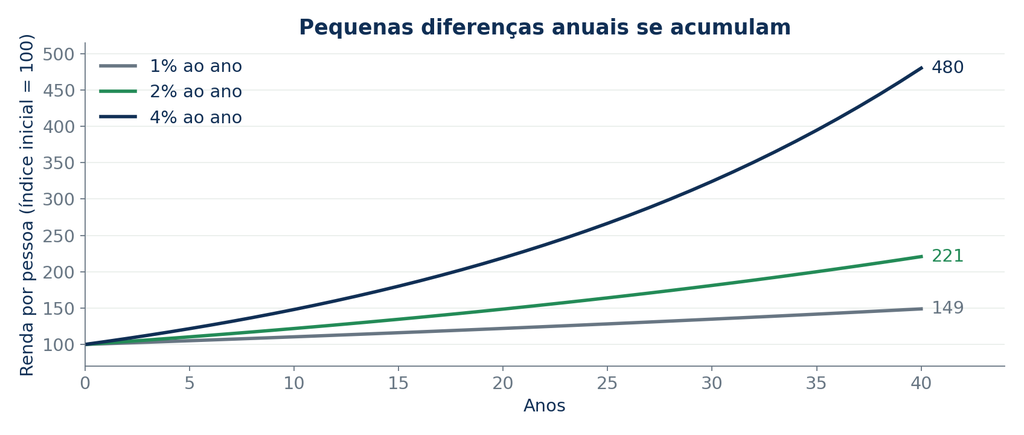

Renda real por pessoa com índice inicial 100, crescendo 1%, 2% e 4% ao ano durante 40 anos.

Fonte: elaboração didática. Dados hipotéticos, salvo indicação expressa.

Partindo de 100, após 40 anos os níveis aproximados são 149, 221 e 480. São trajetórias hipotéticas, não previsões de países.

Diferenças anuais aparentemente pequenas se acumulam. Sustentar crescimento exige compreender suas fontes.

← Menu

## 04 - Comparações entre países

O livro compara trajetórias históricas de países com diferentes níveis e ritmos de crescimento. O contraste mostra que posições relativas podem mudar.

Para comparar padrão de vida, observe PIB real por habitante e poder de compra. Para estudar eficiência produtiva, também é útil examinar produto por trabalhador ou por hora.

Diferenças em participação no trabalho, horas trabalhadas e estrutura etária ajudam a explicar por que produto por habitante e produtividade não são a mesma medida.

Os valores históricos apresentados no capítulo pertencem ao período da edição, não à conjuntura atual.

← Menu

## 05 - O significado de produtividade

**Produtividade do trabalho** é a quantidade produzida por unidade de trabalho utilizada.

$$Produtividade=\frac{Produto\ real}{Horas\ trabalhadas}$$

Uma padaria produz 800 pães em 40 horas de trabalho: 20 pães por hora. Se passa a produzir 1.000 com as mesmas horas, a produtividade cresce 25%.

Trabalhar mais horas pode elevar o produto total sem elevar a produtividade. Máquinas melhores, organização, qualificação e tecnologia podem aumentar o produto por hora.

A medida agregada não revela, sozinha, como os ganhos serão distribuídos.

← Menu

## 06 - A ilha como modelo

O exemplo de Robinson Crusoé simplifica a relação entre produção e consumo. Em uma ilha sem comércio, o padrão material de vida depende do que a pessoa consegue produzir.

Uma rede melhor permite pescar mais no mesmo tempo. Aprender uma técnica também. A disponibilidade de peixes e as condições naturais afetam o resultado.

Na sociedade, comércio e especialização tornam as relações mais complexas, mas permanece a pergunta: **o que permite produzir mais valor por unidade de trabalho?**

É preciso estudar os meios de produção, as habilidades, os recursos e o conhecimento disponíveis.

← Menu

## 07 - Capital físico

Capital físico é o estoque de equipamentos e estruturas usados na produção. Inclui máquinas, ferramentas, instalações e infraestrutura produtiva.

Ele próprio foi produzido. Por isso, pode ser ampliado por investimento, mas se desgasta e se torna obsoleto.

Um computador aumenta a produtividade somente se puder ser utilizado adequadamente, com energia, manutenção, programas e pessoal preparado.

**Capital por trabalhador** importa mais para a produtividade individual do que o estoque total isolado. Uma economia pode ampliar máquinas e população em ritmos que mantenham esse indicador constante.

← Menu

## 08 - Capital humano

Capital humano reúne conhecimentos e capacidades incorporados às pessoas por educação, experiência, treinamento e saúde.

Sua formação exige recursos e tempo. Estudar envolve custos diretos e o custo de oportunidade do trabalho ou de outras atividades que deixam de ser realizadas.

Não basta contar anos de escolaridade: aprendizagem, condições de permanência e possibilidade de aplicar as competências também importam.

A educação pode beneficiar outras pessoas por difusão de ideias e melhor organização. Essas externalidades ajudam a explicar o interesse público em ampliar acesso e qualidade.

← Menu

## 09 - Recursos naturais

Terra, água, florestas e depósitos minerais são recursos fornecidos pela natureza. Alguns se renovam sob determinadas condições de manejo. Outros possuem estoques finitos.

Sua disponibilidade pode favorecer a produção, mas não garante renda alta por habitante. Conhecimento, instituições, infraestrutura e distribuição dos rendimentos afetam sua utilização.

Países com poucos recursos naturais podem produzir bens e serviços de alto valor e importar insumos.

O conceito econômico de escassez inclui custos de acesso, qualidade, localização e efeitos ambientais, e não apenas existência física de um recurso.

← Menu

## 10 - Conhecimento tecnológico

Tecnologia é o conhecimento sobre maneiras de transformar recursos em produtos. Pode aparecer em processos, organização e novos bens, além de equipamentos visíveis.

**Capital humano** é a capacidade das pessoas de compreender e aplicar conhecimento. **Tecnologia** é o conhecimento disponível sobre como produzir.

Uma receita pode existir sem que todos saibam executá-la. Ensinar a receita amplia capital humano. Descobrir uma receita melhor amplia conhecimento tecnológico.

Parte do conhecimento circula livremente. Outra parte permanece protegida por segredo, patente ou dificuldade de reprodução.

← Menu

## 11 - Uma função de produção agregada

$$Y=A\,F(L,K,H,N)$$

$Y$ é o produto, $L$ o trabalho, $K$ o capital físico, $H$ o capital humano e $N$ os recursos naturais. $A$ representa o estado da tecnologia.

Com retornos constantes de escala, multiplicar todos os fatores por uma mesma proporção multiplica o produto nessa proporção.

Dividindo por $L$:

$$\frac{Y}{L}=A\,F\left(1,\frac{K}{L},\frac{H}{L},\frac{N}{L}\right)$$

A expressão organiza os determinantes da produtividade. Não informa automaticamente a importância empírica de cada fator.

← Menu

## 12 - Retornos de escala e produto marginal

**Retornos de escala** perguntam o que acontece quando todos os fatores variam juntos. **Produto marginal** pergunta o que acontece ao aumentar um fator, mantendo os demais constantes.

Uma função pode ter retornos constantes de escala e produto marginal decrescente do capital.

Exemplo: em $Y=\sqrt{KL}$, duplicar $K$ e $L$ duplica $Y$. Mas, mantendo $L=1$, elevar $K$ de 1 para 4 aumenta $Y$ de 1 para 2, enquanto elevar $K$ de 4 para 7 aumenta $Y$ em apenas 0,65.

O ganho de mais máquinas depende dos outros fatores disponíveis.

← Menu

## 13 - Jogo rápido: identificar o fator

1. Uma empresa instala fornos adicionais.
2. Trabalhadores aprendem a reduzir perdas no processo.
3. Surge um método produtivo antes desconhecido.
4. A extração de água supera sua reposição.

**Conferir respostas**

1. Acumulação de capital físico. 2. Formação de capital humano e possível melhoria de organização. 3. Avanço tecnológico. 4. Problema de sustentabilidade de um recurso natural. As categorias podem interagir: uma tecnologia nova precisa de pessoas capazes de aplicá-la.

← Menu

## 14 - Poupar para investir

Construir capital exige destinar parte da produção atual a equipamentos e estruturas. Na economia fechada do modelo, isso corresponde a poupar e consumir menos agora.

O benefício esperado é ampliar a produção e o consumo possíveis no futuro. O investimento também precisa compensar a depreciação.

$$K_{t+1}=K_t+I_t-\delta K_t$$

$\delta K_t$ representa o desgaste no período. Investimento bruto positivo não garante aumento do estoque: ele pode ser menor do que a depreciação.

Retomamos a aula 18: o sistema financeiro influencia quais projetos recebem financiamento.

← Menu

## 15 - Rendimentos decrescentes do capital

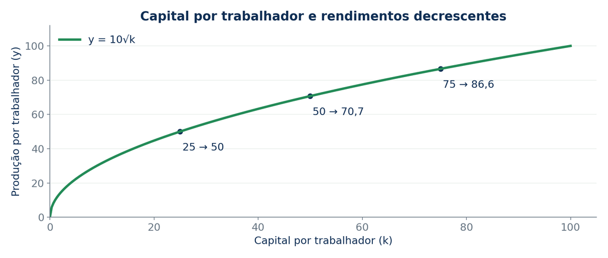

Função de produto por trabalhador crescente e côncava em relação ao capital por trabalhador.

Fonte: elaboração didática. Dados hipotéticos, salvo indicação expressa.

Com os demais fatores constantes, acrescentar capital aumenta o produto, mas os acréscimos tendem a diminuir.

O primeiro equipamento pode resolver uma grande restrição. Muitos equipamentos adicionais para a mesma equipe podem trazer ganhos menores.

← Menu

## 16 - Nível maior e crescimento transitório

Uma taxa de poupança maior acelera a acumulação de capital. Durante a transição, a produtividade cresce mais depressa.

Com rendimentos decrescentes, esse estímulo não sustenta, sozinho, uma taxa de crescimento por trabalhador permanentemente maior. A economia pode alcançar **um nível mais alto** de produto por trabalhador.

Na formulação básica, crescimento persistente por pessoa exige avanço tecnológico e mudanças que evitem a simples diluição dos ganhos marginais.

**“Elevar o nível” e “elevar para sempre a taxa de crescimento” são afirmações diferentes.**

← Menu

## 17 - Estado estacionário: apoio para concursos

Como extensão algébrica do mecanismo do capítulo, considere população e tecnologia constantes. Por trabalhador:

$$\Delta k=s f(k)-\delta k$$

O estado estacionário satisfaz $s f(k^*)=\delta k^*$. O investimento repõe exatamente o desgaste, mantendo o capital por trabalhador.

**Exemplo:** se $s=0{,}20$, $y^*=100$ e $\delta=0{,}10$, então o investimento é 20, $k^*=20/0{,}10=200$ e o consumo é 80.

Essa formalização ajuda a interpretar questões de Solow, sem confundir estado estacionário com ausência universal de progresso técnico.

← Menu

## 18 - O efeito de alcance

O **efeito de alcance**, ou *catch-up*, descreve a possibilidade de economias com pouco capital por trabalhador crescerem rapidamente ao acumular capital e adotar tecnologias existentes.

O mesmo equipamento pode produzir um ganho maior onde ele ainda é escasso.

Isso não implica que todos os países pobres necessariamente alcançarão os ricos. Educação, saúde, instituições, infraestrutura, estabilidade e acesso a tecnologias condicionam o processo.

Compare economias com condições relevantes semelhantes. Convergência condicional não equivale a uma garantia automática de convergência mundial.

← Menu

## 19 - Investimento vindo do exterior

O investimento estrangeiro permite ampliar capital sem depender apenas da poupança doméstica.

**Investimento direto:** o investidor participa do controle ou gestão de uma atividade produtiva. **Investimento em carteira:** adquire títulos ou participações sem a mesma relação de controle.

Uma fábrica estrangeira pode ampliar emprego, produtividade e PIB doméstico. Parte de seus rendimentos pode ser enviada ao exterior, fazendo o ganho da renda nacional diferir do ganho do PIB.

Transferência de tecnologia e aprendizagem são benefícios possíveis, cujo alcance depende dos vínculos com a economia local.

← Menu

## 20 - Educação e acesso às oportunidades

Escolas, formação profissional e pesquisa ampliam capacidades produtivas. O retorno privado pode diferir do retorno social, devido a externalidades e restrições de financiamento.

Uma família pode não conseguir manter uma criança na escola mesmo quando o retorno futuro é elevado. Renda insuficiente e necessidade de trabalho imediato dificultam a decisão.

Políticas de permanência e qualidade procuram enfrentar esses obstáculos. A migração de pessoas qualificadas também modifica a distribuição internacional do capital humano.

Avaliar resultados exige observar aprendizagem e condições de uso das competências, além do gasto realizado.

← Menu

## 21 - Saúde, nutrição e produtividade

Uma população mais saudável consegue estudar, trabalhar e aprender em melhores condições. Nutrição adequada e prevenção reduzem limitações físicas e perdas de tempo produtivo.

O capítulo destaca a contribuição histórica de melhorias nutricionais para a capacidade de trabalho.

Existe também causalidade inversa: renda maior permite consumir melhor e obter cuidados. Pode haver um processo cumulativo entre saúde, renda e produtividade.

Isso recomenda cautela ao interpretar correlações. Pessoas com menor renda não são menos produtivas por uma característica moral: condições materiais podem limitar suas possibilidades.

← Menu

## 22 - Instituições e estabilidade

Investir envolve abrir mão de recursos agora em troca de retornos futuros. Insegurança jurídica, corrupção, violência e risco de expropriação podem encarecer ou impedir projetos.

Proteção de direitos, cumprimento de contratos e funcionamento previsível das instituições ajudam a coordenar trocas e investimentos.

Estabilidade não significa ausência de democracia, conflitos ou mudanças de política. Significa que regras e decisões possam ser conhecidas, contestadas e cumpridas por procedimentos confiáveis.

A qualidade institucional também envolve proteger pessoas e interesses coletivos, não apenas assegurar rendimentos privados.

← Menu

## 23 - Comércio e especialização

O comércio pode ampliar mercados, permitir especialização e dar acesso a insumos e tecnologias. O capítulo contrasta estratégias de isolamento com maior integração internacional.

O ganho agregado potencial não garante que todos os setores e trabalhadores ganhem. Ajustes podem exigir requalificação, proteção de renda e investimento em novas capacidades.

Localização geográfica, custos logísticos e acesso a portos afetam oportunidades comerciais.

Uma estratégia de desenvolvimento precisa examinar o que se exporta, o aprendizado produtivo e a capacidade de absorver tecnologia, além da simples quantidade de comércio.

← Menu

## 24 - Pesquisa e desenvolvimento

Ideias podem beneficiar muitas pessoas ao mesmo tempo. Quando o inovador não consegue receber todo o benefício social, o investimento privado em pesquisa pode ficar abaixo do desejável.

Pesquisa pública, universidades, financiamento competitivo e apoio à difusão procuram enfrentar esse problema. Patentes oferecem exclusividade temporária para criar incentivos, com custos de acesso durante sua vigência.

O desenho da política envolve um compromisso entre **incentivar a criação e ampliar a utilização do conhecimento**.

A incerteza sobre quais inovações funcionarão exige avaliação e possibilidade de corrigir projetos.

← Menu

## 25 - Recursos naturais limitam o crescimento?

O capítulo apresenta o debate entre a finitude de recursos e a capacidade de inovação, substituição e conservação.

Escassez pode estimular técnicas que utilizam menos material ou novas fontes de energia. Entretanto, preços nem sempre incorporam externalidades ambientais e perdas irreversíveis.

Portanto, a possibilidade de substituição não prova que todo limite ecológico desaparecerá. A análise exige distinguir recursos, tecnologias disponíveis, custos e tempo de adaptação.

**Crescimento do produto e sustentabilidade são dimensões relacionadas, mas não equivalentes.**

← Menu

## 26 - População: mais produtores e consumidores

Uma população maior amplia a força de trabalho e também o número de pessoas que utilizam a produção. Assim, pode elevar o PIB total sem elevar o PIB por habitante.

Se o capital cresce menos do que o número de trabalhadores, cai o capital por trabalhador. Esse efeito é chamado de **diluição do capital**.

Educação, estrutura etária, participação no trabalho e disponibilidade de infraestrutura modificam o resultado.

No modelo com crescimento populacional $n$, manter $k$ exige investimento para depreciação e novos trabalhadores: aproximadamente $(\delta+n)k$.

← Menu

## 27 - Malthus e a capacidade de inovar

Malthus temia que o crescimento populacional pressionasse alimentos e recursos, mantendo grande parte da população próxima da subsistência.

Avanços agrícolas e tecnológicos permitiram aumentos de produtividade que essa previsão não incorporava adequadamente.

O capítulo acrescenta que mais pessoas também podem significar mais pesquisadores, invenções e intercâmbio de ideias. Esse efeito depende de educação, instituições e conexão entre pessoas.

O debate não se resolve apenas contando habitantes. É necessário examinar **produtividade, distribuição, inovação e pressão ambiental**.

← Menu

## 28 - Avaliação de políticas e ajuda externa

Gastar mais em uma política não garante que ela alcance seu objetivo. A avaliação compara resultados com o que provavelmente ocorreria sem a intervenção.

Experimentos com atribuição aleatória podem ajudar a identificar efeitos de ações específicas, como incentivos educacionais ou medidas de saúde. O capítulo apresenta essa abordagem no debate sobre ajuda ao desenvolvimento.

É preciso observar validade da comparação, duração dos efeitos e possibilidade de aplicar o resultado em outro contexto.

Uma intervenção local bem-sucedida fornece evidência importante, mas não substitui o estudo das instituições e restrições de uma economia inteira.

← Menu

## 29 - Jogo rápido: o crescimento permanece?

1. Uma economia passa a poupar mais. O modelo de rendimentos decrescentes garante crescimento maior para sempre?
2. O PIB cresce 3% e a população 3%. O produto por habitante aumenta?
3. Uma fábrica estrangeira amplia o PIB. Toda renda adicional fica necessariamente no país?

**Conferir respostas**

1. Não. Há transição para um nível mais alto, mantidas as demais condições. 2. Não, se as taxas forem exatamente iguais. 3. Não. Parte dos rendimentos pode ser remetida ao exterior. Ainda assim, podem existir ganhos internos de salários, aprendizagem e produção.

← Menu

## 30 - Conclusão: capacidade e condições de vida

Crescimento persistente por habitante depende de ampliar a capacidade de produzir. Capital, formação, saúde, recursos e conhecimento atuam de forma interdependente.

Políticas afetam incentivos e oportunidades, mas seus resultados dependem de instituições, financiamento, implementação e condições iniciais.

**A produtividade amplia o que uma sociedade pode oferecer. A distribuição e as decisões coletivas influenciam como essa possibilidade chega às pessoas.**

A próxima aula examina justamente essa passagem, estudando desigualdade, pobreza e critérios para redistribuição.

← Menu

## Exercícios de concursos públicos

Oito exercícios selecionados. Nos itens de julgamento, use **C (certo/verdadeiro)** ou **E (errado/falso)**. Leia os enunciados antes de abrir as respostas. As fontes e as adaptações estão identificadas em cada questão.

### Questão 01

FGV, ALE/PR, Analista Legislativo, Economista, 2024, tipo 1 · questão 57

Solow: s=20%, y=100, depreciação=10%, população e tecnologia constantes. No estado estacionário, quais são k, i e c?

1. 200; 20; 80
2. 200; 80; 20
3. 100; 40; 60
4. 800; 80; 20
5. 1000; 100; 0

Redação sintetizada para uso didático; dados e resposta preservados.

[Prova original](https://conhecimento.fgv.br/sites/default/files/concursos/analista-legislativo-economistae2cns04-tipo-1.pdf) · [Gabarito oficial](https://conhecimento.fgv.br/sites/default/files/concursos/ale-pr-gabarito-definitivo-cargos-do-edital-2.pdf)

Resposta comentada

### Questão 02

Cebraspe, TCE/PA, Auditor de Controle Externo, Fiscalização, Economia, 2016 · questão 71

Patentes e apoio público à pesquisa podem influenciar o progresso técnico e o crescimento persistente da renda por trabalhador.

**( ) C ( ) E**

Redação sintetizada para uso didático; dados e resposta preservados.

[Prova original](https://cdn.cebraspe.org.br/concursos/TCE_PA_16/arquivos/251TCEPA_027_01.pdf) · [Gabarito oficial](https://cdn.cebraspe.org.br/concursos/TCE_PA_16/arquivos/Gab_Definitivo_251TCEPA_027_01.pdf)

Resposta comentada

### Questão 03

CESPE, Câmara dos Deputados, Analista Legislativo / Assistente Técnico, FC de Consultor Legislativo, Área V, 2002 · questão 75, 2º item

Os modernos modelos de crescimento endógeno estabelecem um impacto positivo da concentração de renda sobre o potencial de crescimento. Concentrando-se a renda, elevar- se-á a poupança, o que viabilizará um maior investimento e aumentará o crescimento potencial.

**( ) C ( ) E**

Item original C/E, com normalização de espaçamento. A prova autoriza reprodução com indicação da fonte.

[Prova original](https://cdn.cebraspe.org.br/concursos/_antigos/2003/camaradosdeputados/ARQUIVOS/area_05.pdf) · [Gabarito oficial](https://cdn.cebraspe.org.br/concursos/_antigos/2003/CAMARADOSDEPUTADOS/Arquivos/Gab_Def_CD.pdf)

Resposta comentada

### Questão 04

CESPE, Câmara dos Deputados, Analista Legislativo / Assistente Técnico, FC de Consultor Legislativo, Área V, 2002 · questão 75, 3º item

As políticas sociais do tipo bolsa-escola (benefício monetário a uma população específica que tem como contrapartida a escolarização das crianças) podem ser fundamentadas na teoria do capital humano e no círculo vicioso da pobreza.

**( ) C ( ) E**

Item original C/E, com normalização de espaçamento. A prova autoriza reprodução com indicação da fonte.

[Prova original](https://cdn.cebraspe.org.br/concursos/_antigos/2003/camaradosdeputados/ARQUIVOS/area_05.pdf) · [Gabarito oficial](https://cdn.cebraspe.org.br/concursos/_antigos/2003/CAMARADOSDEPUTADOS/Arquivos/Gab_Def_CD.pdf)

Resposta comentada

### Questão 05

CESPE, Senado Federal, Consultor Legislativo, Área 14, 2002 · questão 64, 5º item

O nível socialmente ótimo para investimento em treinamento de mão-de-obra é aquele que resulta em uma taxa de retorno igual àquela resultante de investimentos realizados pela sociedade em outras formas de capital.

**( ) C ( ) E**

Item original C/E, com normalização de espaçamento. A prova autoriza reprodução com indicação da fonte.

[Prova original](https://cdn.cebraspe.org.br/concursos/_antigos/2002/senado/Arquivos/area_14_LEGISL_1Et.pdf) · [Gabarito oficial](https://cdn.cebraspe.org.br/concursos/_antigos/2002/senado/Arquivos/Gab_Def-SENADO.pdf)

Resposta comentada

### Questão 06

Cebraspe, SEE/DF, Analista de Gestão Educacional, Economia, 2017 · questão 115

Adiar a entrada dos jovens no trabalho para ampliar sua formação pode tornar benéfico um crescimento maior da população em idade ativa que da força de trabalho.

**( ) C ( ) E**

Redação sintetizada para uso didático; dados e resposta preservados.

[Prova original](https://cdn.cebraspe.org.br/concursos/SEE_16_DF/arquivos/291_SEEDF_007_01.pdf) · [Gabarito oficial](https://cdn.cebraspe.org.br/concursos/SEE_16_DF/arquivos/Gab_Definitivo_291_SEEDF_007_01.pdf)

Resposta comentada

### Questão 07

FGV, ALE/PR, Analista Legislativo, Economista, 2024, tipo 1 · questão 36

Ao estudar, alguém abandona um emprego. Como se classifica o rendimento sacrificado?

1. Monetário
2. Contábil
3. Oportunidade
4. Irrecuperável
5. Aluguel

Redação sintetizada para uso didático; dados e resposta preservados.

[Prova original](https://conhecimento.fgv.br/sites/default/files/concursos/analista-legislativo-economistae2cns04-tipo-1.pdf) · [Gabarito oficial](https://conhecimento.fgv.br/sites/default/files/concursos/ale-pr-gabarito-definitivo-cargos-do-edital-2.pdf)

Resposta comentada

### Questão 08

CESPE, Senado Federal, Consultor Legislativo, Área 14, 2002 · questão 56, 4º item

Quando a produtividade marginal do capital excede o custo do capital, as empresas tendem a reduzir o estoque de capital, contraindo, assim, o investimento líquido.

**( ) C ( ) E**

Item original C/E, com normalização de espaçamento. A prova autoriza reprodução com indicação da fonte.

[Prova original](https://cdn.cebraspe.org.br/concursos/_antigos/2002/senado/Arquivos/area_14_LEGISL_1Et.pdf) · [Gabarito oficial](https://cdn.cebraspe.org.br/concursos/_antigos/2002/senado/Arquivos/Gab_Def-SENADO.pdf)

Resposta comentada

**Gabarito resumido e resoluções comentadas**

| Questão | 01 | 02 | 03 | 04 | 05 | 06 | 07 | 08 |
| --- | --- | --- | --- | --- | --- | --- | --- | --- |
| Resposta | A | C | E | C | C | C | C | E |

**Questão 01: A**

$i=sy=20$; $c=(1-s)y=80$. No estado estacionário, $\delta k=i$, portanto $k=20/0{,}10=200$. Estoque de capital e investimento por período são grandezas diferentes.

Voltar ao enunciado

**Questão 02: C**

Conhecimento pode gerar benefícios além de quem o criou. Políticas de inovação alteram incentivos e difusão. Patentes envolvem uma escolha entre incentivo à pesquisa e limitação temporária da concorrência; apoio público exige avaliação.

Voltar ao enunciado

**Questão 03: E**

O item apresenta como universal uma relação que não é garantida. Concentração pode limitar educação, saúde, acesso ao crédito e oportunidades produtivas. A taxa de poupança é apenas um canal; crescimento depende de instituições, capital humano, tecnologia e utilização dos recursos.

Voltar ao enunciado

**Questão 04: C**

Uma transferência condicionada à escolarização pode aliviar a restrição de renda presente e favorecer formação futura. A fundamentação econômica não garante, por si, que qualquer desenho seja eficaz: qualidade da educação e acesso também importam.

Voltar ao enunciado

**Questão 05: C**

Na margem, recursos escassos devem ser comparados pelo retorno social das alternativas. Se formação gera retorno social maior, deslocar recursos para ela pode elevar o resultado agregado. A igualdade marginal pressupõe avaliação comparável de riscos, custos e benefícios externos.

Voltar ao enunciado

**Questão 06: C**

A participação menor não representa necessariamente deterioração. Quando decorre de escolarização efetiva, pode elevar a produtividade futura. O efeito depende de aprendizado, condições de permanência e oportunidades posteriores.

Voltar ao enunciado

**Questão 07: C**

É custo de oportunidade: remuneração da melhor alternativa abandonada. Avaliar formação exige considerar mensalidades, materiais, tempo e renda sacrificada, comparando-os aos benefícios futuros.

Voltar ao enunciado

**Questão 08: E**

Retorno marginal do capital acima de seu custo constitui incentivo para ampliar, não reduzir, o estoque. A relação ajuda a compreender o investimento; não elimina limites de financiamento nem incerteza.

Voltar ao enunciado

← Menu